# act_report

## Report: act_report

This report explains the insights generated and the visualization done during the wrangling process to better communicate my findings. My insights are basically from the understanding of the goal of the cleaned dataset, which is to discover the factors that may influence the ratings(low or high) of the dogs.

Also, it was discovered that people tend to prefer dogs in a certain dog stage than the others. In the cleaned dataset, it was seen that people prefer dogs in the dog stage of 'doggopuppo' which made it have higher tweet ratings than the other dog stages. It may probably be because there are some features in the dogs in the dog stage 'doggopuppo' people prefer to others.

Worth mentioning also is the favorite/likes count. This is also a great factor that influenced the tweet ratings.

Realistically, going on twitter and searching through the 'trending topics' we would see that favorite count, retweet count, number of engagements, the time the tweet was generated amongst others on a particular topic are huge factors that influence the ratings of that topic above others. The example cited is an interesting way to better justify the insights provided and the visualization done in the project.

Below is the graphical representation of how the number of images affects the tweet ratings.

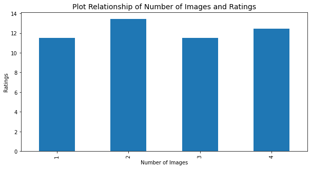